# DA 460 - Lab 7

Marjorie Blanco

08 August, 2018

# Handout 7 R: Introduction to Simple Linear Regression

## The data

```r
# Load the nc data set into our workspace.
download.file("http://www.openintro.org/stat/data/mlb11.RData", destfile = "mlb11.RData")
load("mlb11.RData")
```

### Exercise 1

What type of plot would you use to display the relationship between `runs` and one of the other numerical variables? Plot this relationship using the variable `at_bats` as the predictor. Does the relationship look linear? If you knew a team’s `at_bats`, would you be comfortable using a linear model to predict the number of runs?

A scatter plot is the best plot to display the relationship between two variables. The relationship between `at_bats` and `runs` appear to be linear. If you knew a team’s at_bats, I would not be comfortable using a linear model to predict the number of run but with reservations until I can check the linear regression assumptions (validity of the model).

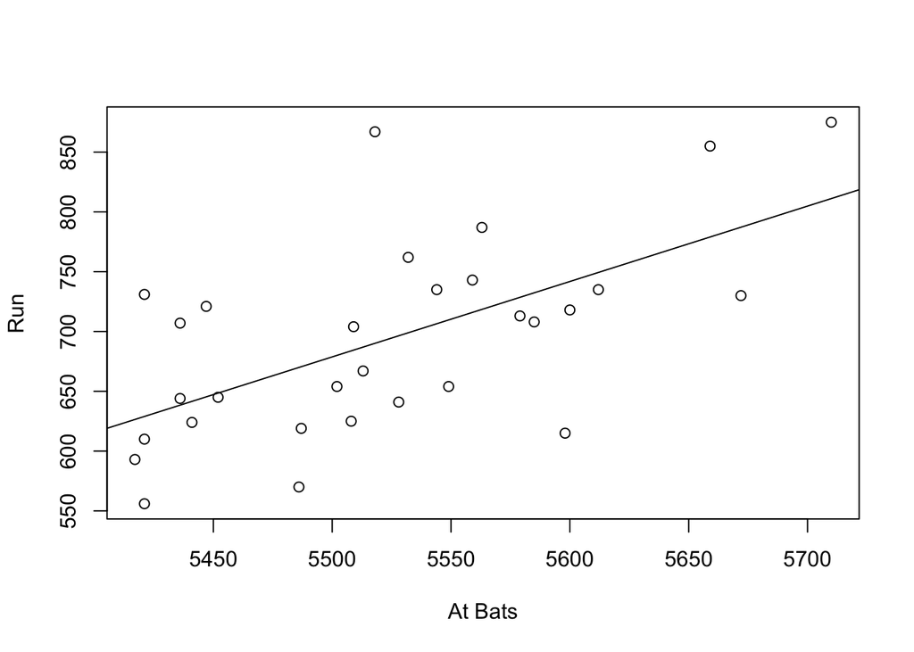

```r
fit <- lm(mlb11$runs ~ mlb11$at_bats)
plot(mlb11$at_bats, mlb11$runs,
    xlab="At Bats",
    ylab="Run")
abline(fit)
```

```r
# quantify the strength of the relationship with the correlation coefficient
model_cor <- cor(mlb11$at_bats, mlb11$runs)
model_cor
```

```
## [1] 0.610627
```

The correlation coefficient is 0.610627, which indicates a moderate uphill (positive) relationship.

## Sum of squared residuals

### Exercise 2

Looking at your plot from the previous exercise, describe the relationship between these two variables. Make sure to discuss the form, direction, and strength of the relationship as well as any unusual observations.

The relationship seems to be a little dispersed. The distribution of the points seems to grow in a positive (upward) direction with some leverage and the relationship seems to have a positive correlation. The correlation coefficient is 0.610627, which indicates a moderate uphill (positive) relationship. There are some unusual observations that might be outliers.

### Exercise 3

Using plot_ss, choose a line that does a good job of minimizing the sum of squares. Run the function several times. What was the smallest sum of squares that you got? How does it compare to your neighbors?

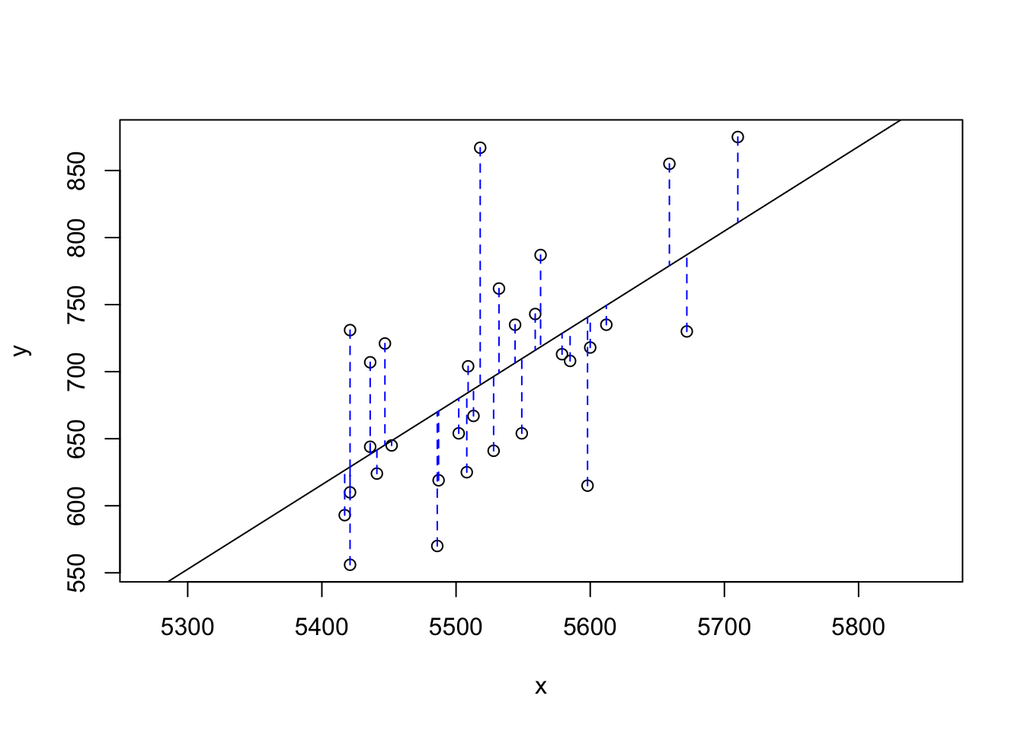

```
## Click two points to make a line.

## Call:
## lm(formula = y ~ x, data = pts)
##
## Coefficients:
## (Intercept)            x
##  -2789.2429       0.6305
##
## Sum of Squares:  123721.9
```

```r
plot_ss(x = mlb11$at_bats,
        y = mlb11$runs)
```

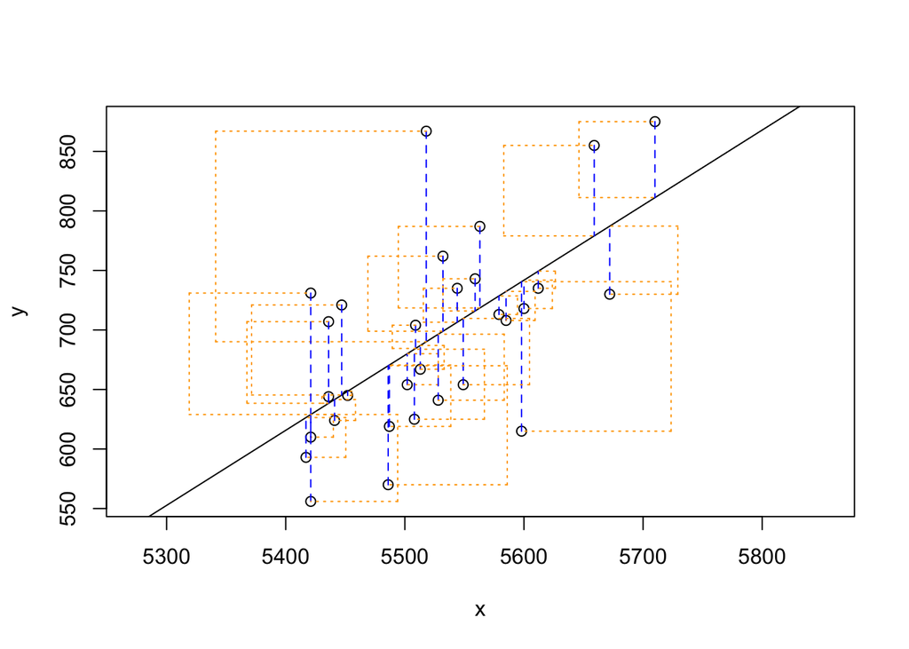

```
## Click two points to make a line.

## Call:
## lm(formula = y ~ x, data = pts)
##
## Coefficients:
## (Intercept)            x
##  -2789.2429       0.6305
##
## Sum of Squares:  123721.9
```

```r
plot_ss(x = mlb11$at_bats, y = mlb11$runs, showSquares = TRUE)
```

The smallest sum of squares is 123721.9. I would expect the neighbors’s sum square to be very similar.

## The linear model

```r
m1 <- lm(runs ~ at_bats, data = mlb11)
summary(m1)
```

```
##
## Call:
## lm(formula = runs ~ at_bats, data = mlb11)
##
## Residuals:
##     Min      1Q  Median      3Q     Max
## -125.58  -47.05  -16.59   54.40  176.87
##
## Coefficients:
##               Estimate Std. Error t value Pr(>|t|)
## (Intercept) -2789.2429   853.6957  -3.267 0.002871 **
## at_bats         0.6305     0.1545   4.080 0.000339 ***
## ---
## Signif. codes:  0 '***' 0.001 '**' 0.01 '*' 0.05 '.' 0.1 ' ' 1
##
## Residual standard error: 66.47 on 28 degrees of freedom
## Multiple R-squared:  0.3729, Adjusted R-squared:  0.3505
## F-statistic: 16.65 on 1 and 28 DF,  p-value: 0.0003388
```

The equation for the regression line is:

$$runs = 0.6305 * atbats - 2789.2429$$

Slope interpretation:

When the at bats goes up by 1, we would expect the runs to go up by 0.6305 when all other variables are held constant.

### Exercise 4

Fit a new model that uses `homeruns` to predict `runs`. Using the estimates from the R output, write the equation of the regression line. What does the slope tell us in the context of the relationship between success of a team and its home runs?

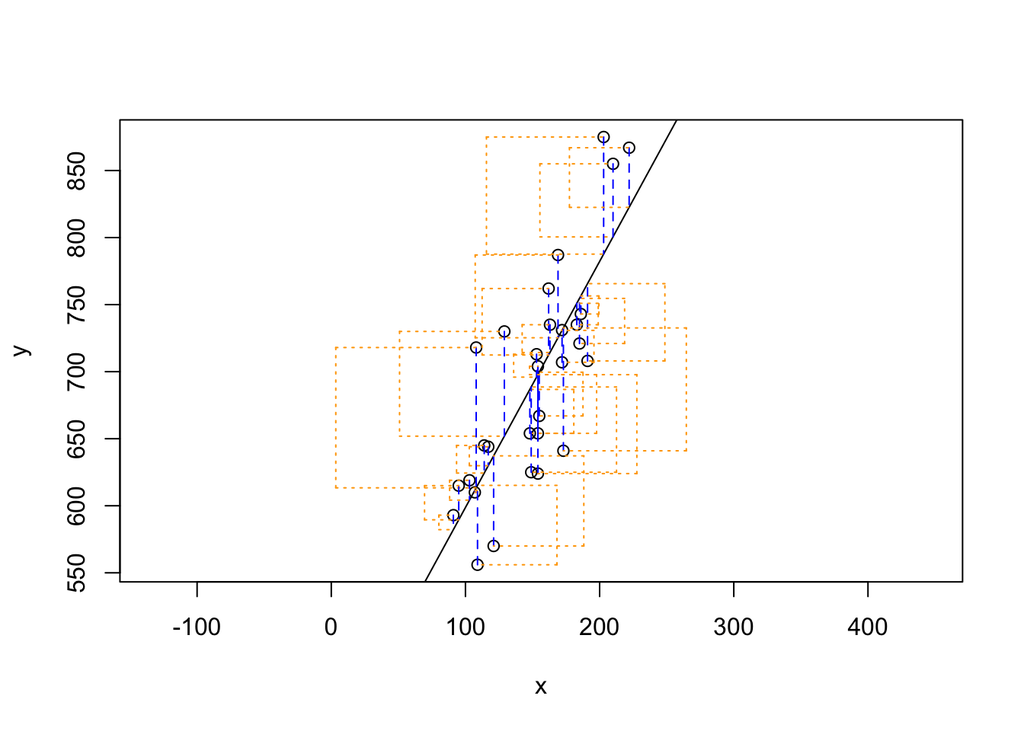

```
## Click two points to make a line.

## Call:
## lm(formula = y ~ x, data = pts)
##
## Coefficients:
## (Intercept)            x
##     415.239        1.835
##
## Sum of Squares:  73671.99
```

```r
plot_ss(x = mlb11$homeruns, y = mlb11$runs, showSquares = TRUE)
```

```r
model_cor <- cor(mlb11$runs, mlb11$homeruns)
model_cor
```

```
## [1] 0.7915577
```

```r
fit <- lm(runs ~ homeruns, data = mlb11)
summary(fit)
```

```
##
## Call:
## lm(formula = runs ~ homeruns, data = mlb11)
##
## Residuals:
##     Min      1Q  Median      3Q     Max
## -91.615 -33.410   3.231  24.292 104.631
##
## Coefficients:
##             Estimate Std. Error t value Pr(>|t|)
## (Intercept) 415.2389    41.6779   9.963 1.04e-10 ***
## homeruns      1.8345     0.2677   6.854 1.90e-07 ***
## ---
## Signif. codes:  0 '***' 0.001 '**' 0.01 '*' 0.05 '.' 0.1 ' ' 1
##
## Residual standard error: 51.29 on 28 degrees of freedom
## Multiple R-squared:  0.6266, Adjusted R-squared:  0.6132
## F-statistic: 46.98 on 1 and 28 DF,  p-value: 1.9e-07
```

The equation for the regression line is:

$$runs = 1.8345 * homeruns + 415.2389$$

The correlation coefficient is 0.7915577, which indicates a strong uphill (positive) relationship. With an increase number of homeruns the more runs the team will score which increases the odds of winning a game.

Slope interpretation:

When home runs goes up by 1, we would expect the runs to go up by 1.8345 when all other variables are held constant.

## Prediction and prediction errors

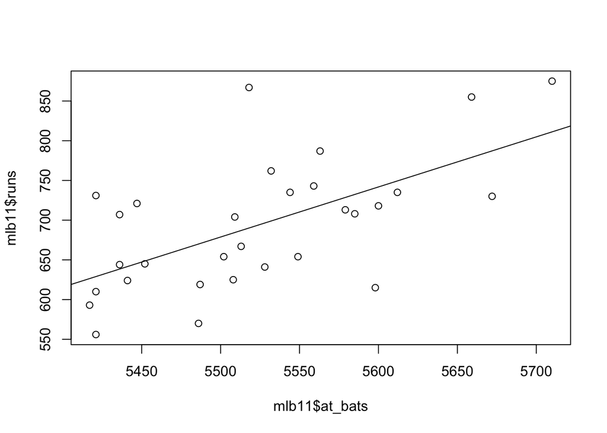

```r
# create a scatterplot with the least squares line laid on top
plot(mlb11$runs ~ mlb11$at_bats)
abline(m1)
```

### Exercise 5

If a team manager saw the least squares regression line and not the actual data, how many runs would he or she predict for a team with 5,578 at-bats? Is this an overestimate or an underestimate, and by how much? In other words, what is the residual for this prediction?

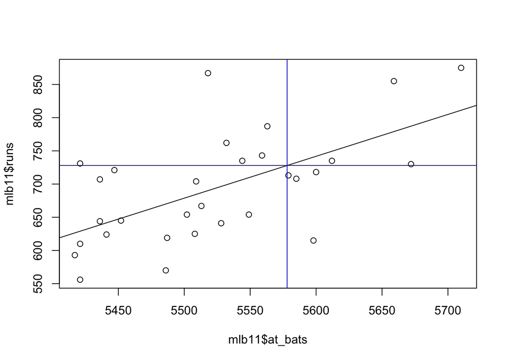

```r
# create a scatterplot with the least squares line laid on top
plot(mlb11$runs ~ mlb11$at_bats)
abline(m1)
abline(v=5578, col="blue")
abline(h=728, col="blue")
```

```r
runs <- function(x = NULL)
{
  y <- 0.6305 * x - 2789.2429
  y <- round(y, 0)
  return(y)
}
pred <- runs(5578)
pred
```

```
## [1] 728
```

```r
new <- data.frame(at_bats = 5578)
fit <- lm(runs ~ at_bats, data = mlb11)
predict(fit, new, interval="predict")
```

```
##       fit      lwr      upr
## 1 727.965 588.4797 867.4503
```

## Model diagnostics

### Exercise 6

Is there any apparent pattern in the residuals plot? What does this indicate about the linearity of the relationship between runs and at-bats?

#### Linearity

Base on the residual plot, the residuals are positioned around zero. This indicates there is a constant linearity relationship between runs and at_bats.

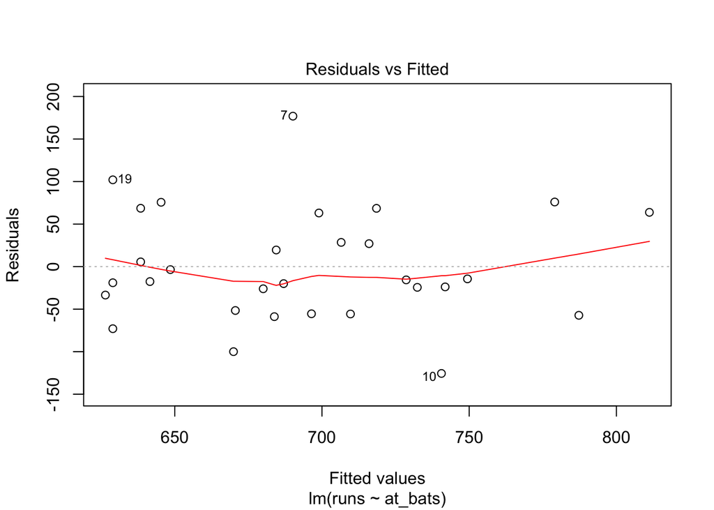

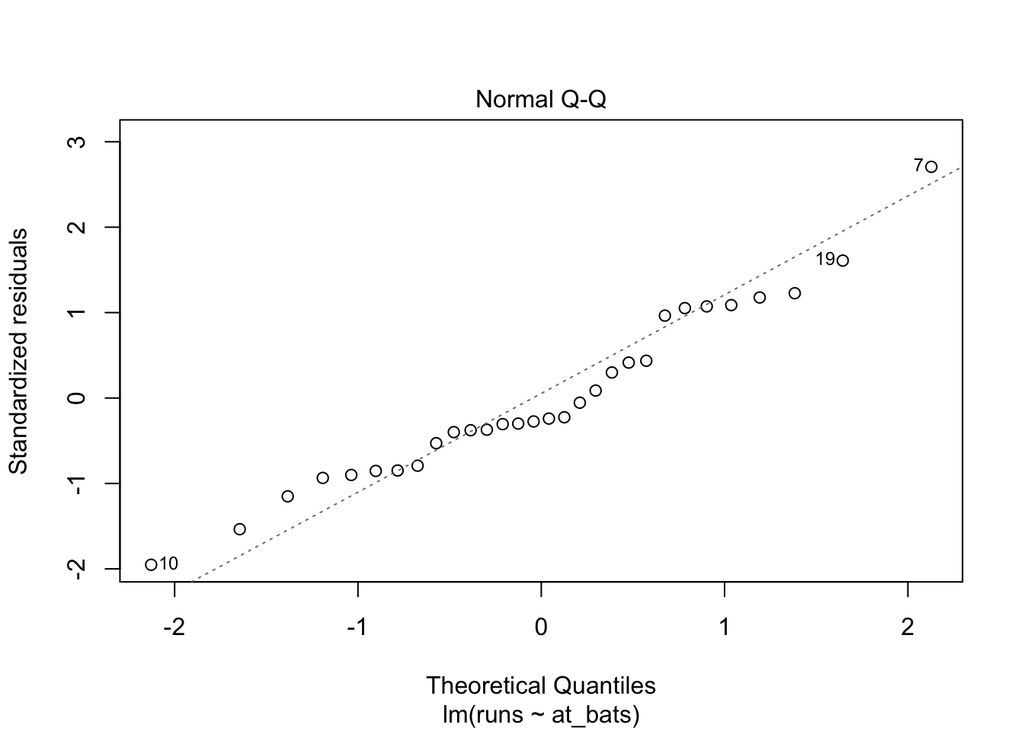

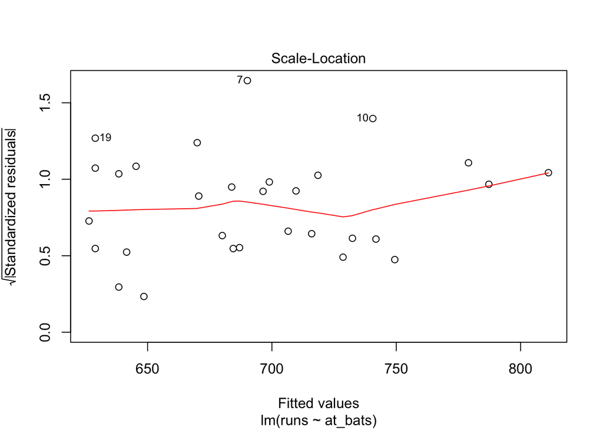

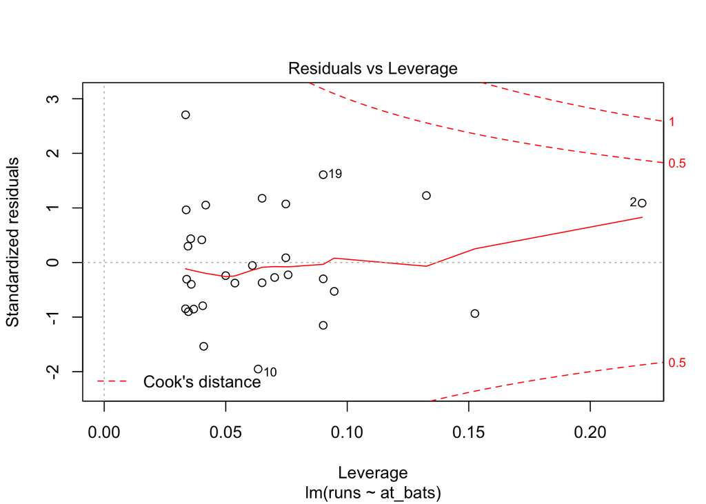

```r
plot(fit)
```

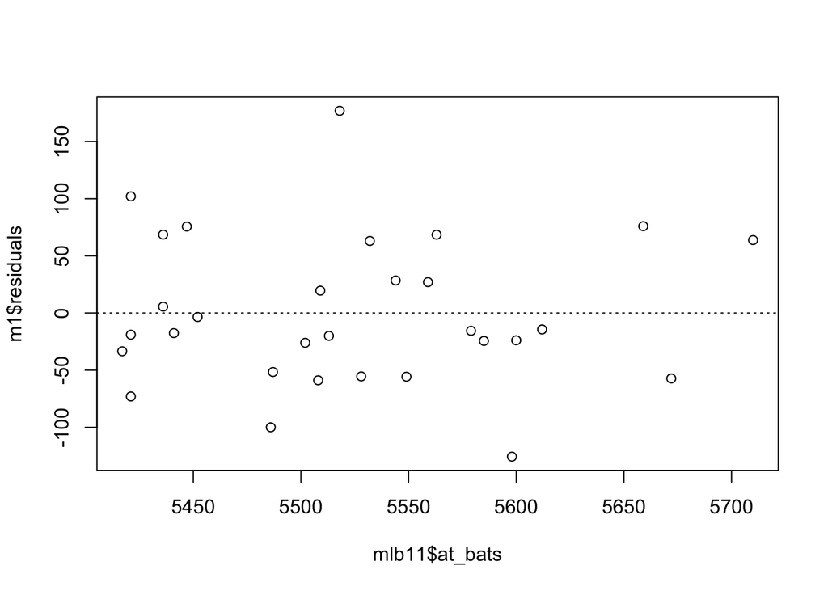

```r
plot(m1$residuals ~ mlb11$at_bats)
abline(h = 0, lty = 3)  # adds a horizontal dashed line at y = 0
```

The residuals show no obvious patterns. The data points appear to be scattered randomly around the dashed line that represents 0. The relationship appears to be linear.

#### Nearly normal residuals

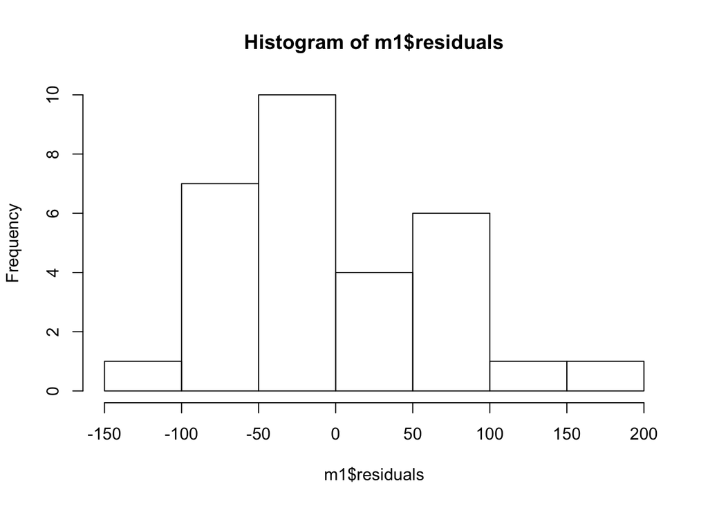

```r
# Nearly normal residuals
hist(m1$residuals)
```

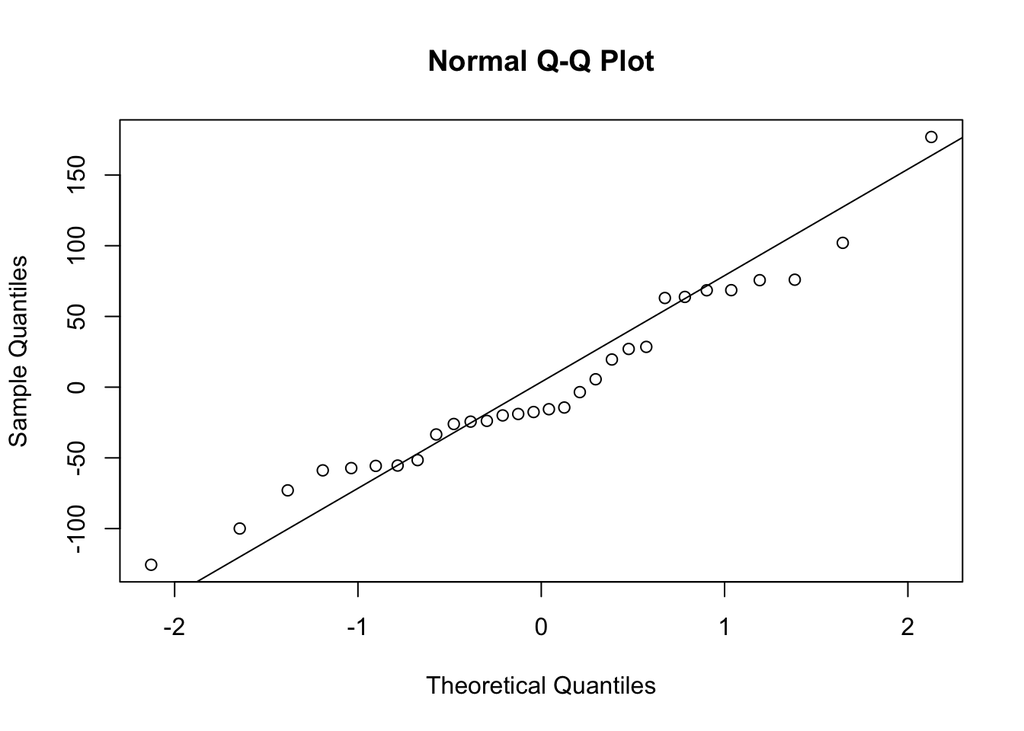

```r
# normal probability plot of the residuals
qqnorm(m1$residuals)
qqline(m1$residuals)  # adds diagonal line to the normal prob plot
```

### Exercise 7

Based on the histogram and the normal probability plot, does the nearly normal residuals condition appear to be met?

Based on both the histogram and the normal probability plot, the normal residuals condition appears to be met. The majority of the data point fall near the line.

### Exercise 8

Based on the plot in (1), does the constant variability condition appear to be met?

Based on the plot in (1), the constant variability condition appear to be met. The constant variability condition is meet when the variability of points around the least squares line remains roughly constant. Not all the point fall near the line. I see a stepwise pattern.